# Maurice Wilkins Centre variants

Anezka Hoskin

2018-09-18

##### Setting up datasets

This cohort contains cases and controls from the Gout data base and cases from the Diabetes Mellitus (DM) and Renal Diabetes (RD) datasets. Even if subjects in the DM and RD datasets do not have diabetes or gout they can not be considered controls because they are not healthy.

All genotypes and phenotypes were extracted from SNPmax.  
The Gout genotypes and phenotypes were in the same phenogeno file. The DM and RD genotypes are in the same file but the phenotypes were seperate. Seperate phenogeno files were extracted from SNPmax and then merged in Excel. The RD rows were coppied into the DM file. The alternative ID’s of DM and RD were checked to delete duplicates in the same file and in the Gout file.

Once duplicates had been removed, the three dataset are merged together. The Core Exome PCA file was then merged with the NZ wide cohort file for further analyses.

##### Polynesian Wide cohort

This combines all polynesian cohorts, West, East and admixed.

##### East and West Polynesian cohorts

These are subsets of the New Zealand wide cohort. The subset is done using ethinicity class, a self-identfying ancestry measure. The association analyses used PCA’s to adjust.

##### Admixed Polynesian cohort

This is a subset of the New Zealand wide cohort based on ethnicity class. These individuals did not exclusivley identify as east or west polynesian. The association analyses used PCA’s to adjust.

##### Ngati Porou Hauora cohort

The genotypes and phenotypes were downloaded from SNPmax. There are PCA values for half of the NPH cohort, in order to keep the cohort numbers analyses were adjusted with GPancestry rather than PCA.

# Variants of interest

NOTE: the following association tests measure the affect of the ‘Alternative’ allele on each phenotype

| Gene | Gene Name | Position | Chromosome | ID | Reference Allele | Alternative Allele | Consequence | Annotation |
| --- | --- | --- | --- | --- | --- | --- | --- | --- |
| LIPE | Lipase E | 42405466 | 19 | rs370955937 | G | A | p.Arg821Cys | missense variant |
| TSC1 | TSC complex subunit 1 | 132905878 | 9 | rs397514880 | G | A | p.Ala567Val | missense variant |
| WFS1 | Wolframin ER transmembrane glycoprotein | 6301612 | 4 | rs756252214 | T | G | p.Val606Gly | missense variant |
| CREB3L2 | cAMP responsive element binding protein 3 like 2 | 137915992 | 7 | rs777894272 | A | G | p.Trp114Arg | missense variant |
| SLC22A3 | Solute Carrier Family 22 Member 3 | 1608647744 | 6 | rs8187715 | C | T | p.Thr44Met | missense variant |

# Cohort Demographics

Demographic data

|  | Polynesian Wide | West Polynesian | East Polynesian | Admixed Polynesian | Ngati Porou Hauora |
| --- | --- | --- | --- | --- | --- |
| Participants (n) | 3075 | 1074 | 1849 | 152 | 585 |
| Gout, n(%) | 1204 ( 44.48 ) | 472 ( 51.08 ) | 690 ( 41.79 ) | 42 ( 31.82 ) | 299 ( 53.3 ) |
| Diabetes, n(%) | 934 ( 33.07 ) | 348 ( 34.05 ) | 543 ( 32.83 ) | 43 ( 29.05 ) | 120 ( 21.24 ) |
| BMI, mean (sd) | 34.47 ( 8.03 ) | 35.51 ( 7.56 ) | 33.74 ( 8.25 ) | 35.36 ( 8 ) | 34.13 ( 8.06 ) |
| Sex (male), n(%) | 1766 ( 58.09 ) | 694 ( 65.23 ) | 985 ( 54 ) | 87 ( 57.24 ) | 390 ( 66.78 ) |
| Age | 47.93 | 45.28 | 50.26 | 38.67 | 53.30 |
| Age Range | 16 - 100 | 16 - 84 | 17 - 100 | 16 - 88 | 17 - 94 |
| Height (cm) | 170.65 ( 9.73 ) | 172.05 ( 9.56 ) | 169.74 ( 9.84 ) | 170.91 ( 8.37 ) | 169.22 ( 9.32 ) |
| Weight (kg) | 100.32 ( 24.92 ) | 105.27 ( 24.28 ) | 96.91 ( 24.5 ) | 103.63 ( 27.77 ) | 97.68 ( 24.47 ) |
| Cholestrol (mmol/L) | 4.79 ( 1.19 ) | 4.77 ( 1.18 ) | 4.8 ( 1.2 ) | 4.75 ( 1.14 ) | 5.01 ( 1.1 ) |
| Low Density Lipids (mmol/L) | 2.72 ( 1 ) | 2.76 ( 1.04 ) | 2.7 ( 0.99 ) | 2.7 ( 0.93 ) | 2.93 ( 1.03 ) |
| High Density Lipids (mmol/L) | 1.14 ( 0.38 ) | 1.11 ( 0.35 ) | 1.16 ( 0.39 ) | 1.17 ( 0.36 ) | 1.17 ( 0.32 ) |
| Triglycerides (mmol/L) | 2.23 ( 1.98 ) | 2.2 ( 1.71 ) | 2.24 ( 1.98 ) | 2.27 ( 3.3 ) | 2.19 ( 1.51 ) |
| Serum Urate (mmol/L) | 0.44 ( 0.12 ) | 0.47 ( 0.12 ) | 0.42 ( 0.12 ) | 0.45 ( 0.12 ) | 0.7 ( 3.3 ) |
| Serum Creatinine (umol/L) | 161.84 ( 181.77 ) | 156.02 ( 167.8 ) | 168.64 ( 193.4 ) | 130.05 ( 138.76 ) | 94.21 ( 46.06 ) |
| HbA1c (mmol/L) | 48.02 ( 21.74 ) | 50.4 ( 20.97 ) | 46.63 ( 21.73 ) | 49.05 ( 27.58 ) | 45.93 ( 15.7 ) |
| EGFR (mL/min/1.73 m2) | 35.9 ( 34.04 ) | 42.45 ( 35.89 ) | 30.92 ( 31.92 ) | 50.17 ( 34.61 ) | 71.78 ( 17.46 ) |
| PCA East Polynesian, n(%) | 1223 ( 52 ) | 0 | 1206 ( 84.99 ) | 17 ( 14.91 ) | 262 ( 83.97 ) |
| PCA West Polynesian, n(%) | 841 ( 35.76 ) | 774 ( 94.51 ) | 8 ( 0.56 ) | 59 ( 51.75 ) | 6 ( 1.92 ) |

**Note:**  
Unless specified data is presented as means (sd). Estimated glomerular filtration rate (EGFR).

# Allele Frequencies and Hardy Weinburg Equilibrium

Genotype frequencies, minor allele frequencies and Hardy Weinberg

|  | Polynesian Wide Total | Polynesian Wide Gout Cases | Polynesian Wide Gout Controls | Polynesian Wide NA | Polynesian Wide Diabetes Cases | Polynesian Wide Diabetes Controls | Polynesian Wide NA | West Polynesian Total | West Polynesian Gout Cases | West Polynesian Gout Controls | West Polynesian NA | West Polynesian Diabetes Cases | West Polynesian Diabetes Controls | West Polynesian NA | East Polynesian Total | East Polynesian Gout Cases | East Polynesian Gout Controls | East Polynesian NA | East Polynesian Diabetes Cases | East Polynesian Diabetes Controls | East Polynesian NA | Ngati Porou Hauora Total | Ngati Porou Hauora Gout Cases | Ngati Porou Hauora Gout Controls | Ngati Porou Hauora NA | Ngati Porou Hauora Diabetes Cases | Ngati Porou Hauora Diabetes Controls | Ngati Porou Hauora NA |
| --- | --- | --- | --- | --- | --- | --- | --- | --- | --- | --- | --- | --- | --- | --- | --- | --- | --- | --- | --- | --- | --- | --- | --- | --- | --- | --- | --- | --- |
| **LIPE (rs370955937)** |  |  |  |  |  |  |  |  |  |  |  |  |  |  |  |  |  |  |  |  |  |  |  |  |  |  |  |  |
| GG | 1496 ( 58.41 ) | 735 ( 58.66 ) | 592 ( 58.27 ) | 169 ( 57.88 ) | 994 ( 59.95 ) | 483 ( 56.43 ) | 19 ( 40.43 ) | 458 ( 47.91 ) | 193 ( 47.42 ) | 200 ( 47.62 ) | 65 ( 50.39 ) | 293 ( 47.8 ) | 163 ( 49.7 ) | 2 ( 13.33 ) | 961 ( 65.06 ) | 496 ( 64.33 ) | 374 ( 66.67 ) | 91 ( 62.76 ) | 650 ( 67.78 ) | 295 ( 60.57 ) | 16 ( 51.61 ) | 366 ( 67.16 ) | 165 ( 67.9 ) | 185 ( 65.84 ) | 16 ( 76.19 ) | 280 ( 67.63 ) | 74 ( 66.07 ) | 12 ( 63.16 ) |
| GA | 927 ( 36.2 ) | 457 ( 36.47 ) | 367 ( 36.12 ) | 103 ( 35.27 ) | 571 ( 34.44 ) | 330 ( 38.55 ) | 26 ( 55.32 ) | 408 ( 42.68 ) | 177 ( 43.49 ) | 178 ( 42.38 ) | 53 ( 41.09 ) | 260 ( 42.41 ) | 137 ( 41.77 ) | 11 ( 73.33 ) | 473 ( 32.02 ) | 253 ( 32.81 ) | 174 ( 31.02 ) | 46 ( 31.72 ) | 280 ( 29.2 ) | 178 ( 36.55 ) | 15 ( 48.39 ) | 161 ( 29.54 ) | 74 ( 30.45 ) | 82 ( 29.18 ) | 5 ( 23.81 ) | 124 ( 29.95 ) | 30 ( 26.79 ) | 7 ( 36.84 ) |
| AA | 138 ( 5.39 ) | 61 ( 4.87 ) | 57 ( 5.61 ) | 20 ( 6.85 ) | 93 ( 5.61 ) | 43 ( 5.02 ) | 2 ( 4.26 ) | 90 ( 9.41 ) | 37 ( 9.09 ) | 42 ( 10 ) | 11 ( 8.53 ) | 60 ( 9.79 ) | 28 ( 8.54 ) | 2 ( 13.33 ) | 43 ( 2.91 ) | 22 ( 2.85 ) | 13 ( 2.32 ) | 8 ( 5.52 ) | 29 ( 3.02 ) | 14 ( 2.87 ) | NA ( NA ) | 18 ( 3.3 ) | 4 ( 1.65 ) | 14 ( 4.98 ) | NA ( NA ) | 10 ( 2.42 ) | 8 ( 7.14 ) | NA ( NA ) |
| LIPE (MAF) | 0.2349 | 0.2310 | 0.2367 | 0.2449 | 0.2283 | 0.2430 | 0.3191 | 0.3075 | 0.3084 | 0.3119 | 0.2907 | 0.3100 | 0.2942 | 0.5000 | 0.1892 | 0.1926 | 0.1783 | 0.2138 | 0.1762 | 0.2115 | 0.2419 | 0.1807 | 0.1687 | 0.1957 | 0.1190 | 0.1739 | 0.2054 | 0.1842 |
| LIPE (HWE) | 0.7417 | 0.3821 | 1.0000 | 0.4300 | 0.3648 | 0.1929 | 0.0960 | 1.0000 | 0.7288 | 0.8202 | 1.0000 | 0.8503 | 1.0000 | 0.1418 | 0.1068 | 0.1636 | 0.1950 | 0.4649 | 1.0000 | 0.0409 | 0.1483 | 1.0000 | 0.2525 | 0.2532 | 1.0000 | 0.4937 | 0.0770 | 1.0000 |
| **TSC1 (rs397514880)** |  |  |  |  |  |  |  |  |  |  |  |  |  |  |  |  |  |  |  |  |  |  |  |  |  |  |  |  |
| GG. | 1746 ( 67.28 ) | 861 ( 67.69 ) | 682 ( 66.47 ) | 203 ( 68.35 ) | 1143 ( 68.08 ) | 573 ( 65.94 ) | 30 ( 63.83 ) | 621 ( 64.62 ) | 262 ( 64.06 ) | 269 ( 63.74 ) | 90 ( 69.23 ) | 387 ( 62.82 ) | 225 ( 68.18 ) | 9 ( 60 ) | 1042 ( 69.28 ) | 551 ( 70.01 ) | 390 ( 68.66 ) | 101 ( 67.79 ) | 706 ( 72.41 ) | 316 ( 63.45 ) | 20 ( 64.52 ) | 378 ( 67.74 ) | 175 ( 69.17 ) | 188 ( 66.43 ) | 15 ( 68.18 ) | 290 ( 68.24 ) | 73 ( 64.04 ) | 15 ( 78.95 ) |
| GA. | 757 ( 29.17 ) | 371 ( 29.17 ) | 306 ( 29.82 ) | 80 ( 26.94 ) | 476 ( 28.35 ) | 266 ( 30.61 ) | 15 ( 31.91 ) | 300 ( 31.22 ) | 132 ( 32.27 ) | 136 ( 32.23 ) | 32 ( 24.62 ) | 204 ( 33.12 ) | 90 ( 27.27 ) | 6 ( 40 ) | 416 ( 27.66 ) | 212 ( 26.94 ) | 160 ( 28.17 ) | 44 ( 29.53 ) | 238 ( 24.41 ) | 169 ( 33.94 ) | 9 ( 29.03 ) | 165 ( 29.57 ) | 73 ( 28.85 ) | 86 ( 30.39 ) | 6 ( 27.27 ) | 123 ( 28.94 ) | 38 ( 33.33 ) | 4 ( 21.05 ) |
| AA. | 92 ( 3.55 ) | 40 ( 3.14 ) | 38 ( 3.7 ) | 14 ( 4.71 ) | 60 ( 3.57 ) | 30 ( 3.45 ) | 2 ( 4.26 ) | 40 ( 4.16 ) | 15 ( 3.67 ) | 17 ( 4.03 ) | 8 ( 6.15 ) | 25 ( 4.06 ) | 15 ( 4.55 ) | NA ( NA ) | 46 ( 3.06 ) | 24 ( 3.05 ) | 18 ( 3.17 ) | 4 ( 2.68 ) | 31 ( 3.18 ) | 13 ( 2.61 ) | 2 ( 6.45 ) | 15 ( 2.69 ) | 5 ( 1.98 ) | 9 ( 3.18 ) | 1 ( 4.55 ) | 12 ( 2.82 ) | 3 ( 2.63 ) | NA ( NA ) |
| TSC1 (MAF) | 0.1813 | 0.1773 | 0.1862 | 0.1818 | 0.1775 | 0.1876 | 0.2021 | 0.1977 | 0.1980 | 0.2014 | 0.1846 | 0.2062 | 0.1818 | 0.2000 | 0.1689 | 0.1652 | 0.1725 | 0.1745 | 0.1538 | 0.1958 | 0.2097 | 0.1747 | 0.1640 | 0.1837 | 0.1818 | 0.1729 | 0.1930 | 0.1053 |
| TSC1 (HWE) | 0.3898 | 1.0000 | 0.6067 | 0.1166 | 0.2416 | 1.0000 | 1.0000 | 0.6116 | 0.8763 | 1.0000 | 0.0423 | 0.9019 | 0.1380 | 1.0000 | 0.5813 | 0.5179 | 0.7685 | 1.0000 | 0.0637 | 0.0893 | 0.5826 | 0.6597 | 0.4982 | 1.0000 | 0.5381 | 1.0000 | 0.7620 | 1.0000 |
| **WFS1 (rs756252214)** |  |  |  |  |  |  |  |  |  |  |  |  |  |  |  |  |  |  |  |  |  |  |  |  |  |  |  |  |
| TT | 2025 ( 78.76 ) | 983 ( 78.02 ) | 812 ( 79.76 ) | 230 ( 78.5 ) | 1329 ( 79.87 ) | 656 ( 76.28 ) | 40 ( 85.11 ) | 838 ( 87.57 ) | 347 ( 85.05 ) | 375 ( 89.29 ) | 116 ( 89.92 ) | 534 ( 86.97 ) | 289 ( 88.11 ) | 15 ( 100 ) | 1086 ( 73.13 ) | 575 ( 74 ) | 410 ( 72.95 ) | 101 ( 69.18 ) | 726 ( 75.39 ) | 336 ( 68.43 ) | 24 ( 77.42 ) | 362 ( 66.18 ) | 164 ( 67.21 ) | 184 ( 65.25 ) | 14 ( 66.67 ) | 295 ( 70.91 ) | 57 ( 50.89 ) | 10 ( 52.63 ) |
| TG | 496 ( 19.29 ) | 255 ( 20.24 ) | 186 ( 18.27 ) | 55 ( 18.77 ) | 302 ( 18.15 ) | 187 ( 21.74 ) | 7 ( 14.89 ) | 111 ( 11.6 ) | 57 ( 13.97 ) | 41 ( 9.76 ) | 13 ( 10.08 ) | 72 ( 11.73 ) | 39 ( 11.89 ) | NA ( NA ) | 360 ( 24.24 ) | 184 ( 23.68 ) | 137 ( 24.38 ) | 39 ( 26.71 ) | 212 ( 22.01 ) | 141 ( 28.72 ) | 7 ( 22.58 ) | 163 ( 29.8 ) | 68 ( 27.87 ) | 90 ( 31.91 ) | 5 ( 23.81 ) | 106 ( 25.48 ) | 48 ( 42.86 ) | 9 ( 47.37 ) |
| .GG | 50 ( 1.94 ) | 22 ( 1.75 ) | 20 ( 1.96 ) | 8 ( 2.73 ) | 33 ( 1.98 ) | 17 ( 1.98 ) | NA ( NA ) | 8 ( 0.84 ) | 4 ( 0.98 ) | 4 ( 0.95 ) | NA ( NA ) | 8 ( 1.3 ) | NA ( NA ) | NA ( NA ) | 39 ( 2.63 ) | 18 ( 2.32 ) | 15 ( 2.67 ) | 6 ( 4.11 ) | 25 ( 2.6 ) | 14 ( 2.85 ) | NA ( NA ) | 22 ( 4.02 ) | 12 ( 4.92 ) | 8 ( 2.84 ) | 2 ( 9.52 ) | 15 ( 3.61 ) | 7 ( 6.25 ) | NA ( NA ) |
| WFS1 (MAF) | 0.1159 | 0.1187 | 0.1110 | 0.1212 | 0.1106 | 0.1285 | 0.0745 | 0.0664 | 0.0797 | 0.0583 | 0.0504 | 0.0717 | 0.0595 | 0.0000 | 0.1475 | 0.1416 | 0.1486 | 0.1747 | 0.1360 | 0.1721 | 0.1129 | 0.1892 | 0.1885 | 0.1879 | 0.2143 | 0.1635 | 0.2768 | 0.2368 |
| WFS1 (HWE) | 0.0050 | 0.2793 | 0.0247 | 0.0514 | 0.0026 | 0.3632 | 1.0000 | 0.0614 | 0.3070 | 0.0433 | 1.0000 | 0.0085 | 0.6155 | 1.0000 | 0.1789 | 0.4608 | 0.4031 | 0.3875 | 0.0543 | 1.0000 | 1.0000 | 0.4870 | 0.2058 | 0.5594 | 0.1952 | 0.1545 | 0.6363 | 0.5252 |
| **CREB3L2 (rs777894272)** |  |  |  |  |  |  |  |  |  |  |  |  |  |  |  |  |  |  |  |  |  |  |  |  |  |  |  |  |
| .AA | 2319 ( 90.66 ) | 1161 ( 92.81 ) | 908 ( 89.46 ) | 250 ( 85.62 ) | 1511 ( 91.3 ) | 764 ( 89.25 ) | 44 ( 93.62 ) | 760 ( 79.58 ) | 332 ( 81.57 ) | 332 ( 79.24 ) | 96 ( 74.42 ) | 494 ( 80.72 ) | 254 ( 77.44 ) | 12 ( 80 ) | 1448 ( 98.17 ) | 761 ( 98.96 ) | 546 ( 97.33 ) | 141 ( 97.24 ) | 941 ( 98.33 ) | 476 ( 97.74 ) | 31 ( 100 ) | 539 ( 99.45 ) | 242 ( 99.59 ) | 276 ( 99.28 ) | 21 ( 100 ) | 409 ( 99.51 ) | 111 ( 99.11 ) | 19 ( 100 ) |
| AG | 231 ( 9.03 ) | 88 ( 7.03 ) | 104 ( 10.25 ) | 39 ( 13.36 ) | 138 ( 8.34 ) | 90 ( 10.51 ) | 3 ( 6.38 ) | 187 ( 19.58 ) | 73 ( 17.94 ) | 84 ( 20.05 ) | 30 ( 23.26 ) | 112 ( 18.3 ) | 72 ( 21.95 ) | 3 ( 20 ) | 27 ( 1.83 ) | 8 ( 1.04 ) | 15 ( 2.67 ) | 4 ( 2.76 ) | 16 ( 1.67 ) | 11 ( 2.26 ) | NA ( NA ) | 3 ( 0.55 ) | 1 ( 0.41 ) | 2 ( 0.72 ) | NA ( NA ) | 2 ( 0.49 ) | 1 ( 0.89 ) | NA ( NA ) |
| GG, | 8 ( 0.31 ) | 2 ( 0.16 ) | 3 ( 0.3 ) | 3 ( 1.03 ) | 6 ( 0.36 ) | 2 ( 0.23 ) | NA ( NA ) | 8 ( 0.84 ) | 2 ( 0.49 ) | 3 ( 0.72 ) | 3 ( 2.33 ) | 6 ( 0.98 ) | 2 ( 0.61 ) | NA ( NA ) | 0 | 0 | 0 | 0 | 0 | 0 | 0 | 0 | 0 | 0 | 0 | 0 | 0 | 0 |
| CREB3L2 (MAF) | 0.0483 | 0.0368 | 0.0542 | 0.0771 | 0.0453 | 0.0549 | 0.0319 | 0.1063 | 0.0946 | 0.1074 | 0.1395 | 0.1013 | 0.1159 | 0.1000 | 0.0092 | 0.0052 | 0.0134 | 0.0138 | 0.0084 | 0.0113 | 0.0000 | 0.0028 | 0.0021 | 0.0036 | 0.0000 | 0.0024 | 0.0045 | 0.0000 |
| CREB3L2 (HWE) | 0.3838 | 1.0000 | 1.0000 | 1.0000 | 1.0000 | 1.0000 | 1.0000 | 0.3985 | 1.0000 | 1.0000 | 1.0000 | 1.0000 | 1.0000 | 1.0000 | 1.0000 | 1.0000 | 1.0000 | 1.0000 | 1.0000 | 1.0000 | 1.0000 | 1.0000 | 1.0000 | 1.0000 | 1.0000 | 1.0000 | 1.0000 | 1.0000 |
| **SLC22A3 (rs8187715)** |  |  |  |  |  |  |  |  |  |  |  |  |  |  |  |  |  |  |  |  |  |  |  |  |  |  |  |  |
| CC | 1791 ( 77.2 ) | 924 ( 77.39 ) | 808 ( 77.32 ) | 59 ( 72.84 ) | 1251 ( 77.85 ) | 479 ( 75.55 ) | 61 ( 77.22 ) | 676 ( 84.18 ) | 308 ( 83.47 ) | 350 ( 85.16 ) | 18 ( 78.26 ) | 477 ( 81.82 ) | 184 ( 90.2 ) | 15 ( 93.75 ) | 1023 ( 72.81 ) | 558 ( 74.2 ) | 427 ( 71.4 ) | 38 ( 69.09 ) | 701 ( 74.89 ) | 277 ( 68.06 ) | 45 ( 72.58 ) | 380 ( 67.38 ) | 169 ( 66.54 ) | 191 ( 66.55 ) | 20 ( 86.96 ) | 288 ( 67.13 ) | 78 ( 66.67 ) | 14 ( 77.78 ) |
| CT | 476 ( 20.52 ) | 243 ( 20.35 ) | 216 ( 20.67 ) | 17 ( 20.99 ) | 328 ( 20.41 ) | 134 ( 21.14 ) | 14 ( 17.72 ) | 124 ( 15.44 ) | 59 ( 15.99 ) | 60 ( 14.6 ) | 5 ( 21.74 ) | 103 ( 17.67 ) | 20 ( 9.8 ) | 1 ( 6.25 ) | 333 ( 23.7 ) | 170 ( 22.61 ) | 151 ( 25.25 ) | 12 ( 21.82 ) | 211 ( 22.54 ) | 109 ( 26.78 ) | 13 ( 20.97 ) | 163 ( 28.9 ) | 77 ( 30.31 ) | 83 ( 28.92 ) | 3 ( 13.04 ) | 127 ( 29.6 ) | 32 ( 27.35 ) | 4 ( 22.22 ) |
| TT., | 53 ( 2.28 ) | 27 ( 2.26 ) | 21 ( 2.01 ) | 5 ( 6.17 ) | 28 ( 1.74 ) | 21 ( 3.31 ) | 4 ( 5.06 ) | 3 ( 0.37 ) | 2 ( 0.54 ) | 1 ( 0.24 ) | 0 ( 0 ) | 3 ( 0.51 ) | 0 ( 0 ) | 0 ( 0 ) | 49 ( 3.49 ) | 24 ( 3.19 ) | 20 ( 3.34 ) | 5 ( 9.09 ) | 24 ( 2.56 ) | 21 ( 5.16 ) | 4 ( 6.45 ) | 21 ( 3.72 ) | 8 ( 3.15 ) | 13 ( 4.53 ) | 0 ( 0 ) | 14 ( 3.26 ) | 7 ( 5.98 ) | 0 ( 0 ) |
| SLC22A3 (MAF) | 0.1254 | 0.1244 | 0.1234 | 0.1667 | 0.1195 | 0.1388 | 0.1392 | 0.0809 | 0.0854 | 0.0754 | 0.1087 | 0.0935 | 0.0490 | 0.0312 | 0.1534 | 0.1449 | 0.1597 | 0.2000 | 0.1384 | 0.1855 | 0.1694 | 0.1817 | 0.1831 | 0.1899 | 0.0652 | 0.1807 | 0.1966 | 0.1111 |
| SLC22A3 (HWE) | 0.0032 | 0.0322 | 0.1520 | 0.0371 | 0.2350 | 0.0069 | 0.0355 | 0.4716 | 1.0000 | 0.7174 | 1.0000 | 0.4609 | 1.0000 | 1.0000 | 0.0019 | 0.0185 | 0.1683 | 0.0262 | 0.0995 | 0.0313 | 0.0575 | 0.4806 | 1.0000 | 0.3357 | 1.0000 | 1.0000 | 0.1467 | 1.0000 |

**Note:**  
Minor allele frequency (MAF), Hardy Weinberg Equilibrium (HWE)

# Type 2 Diabetes logistic regressions

### Polynesian Wide Cohort

Type 2 diabetes association in Polynesian wide cohort

| SNP | n | genotypes | alleles | Unadjusted Beta | Unadjusted SE | Unadjusted OR | Unadjusted LowerCI | Unadjusted UpperCI | Unadjusted P | Adjusted n.adj | Adjusted Beta.adj | Adjusted SE.adj | Adjusted OR.adj | Adjusted LowerCI.adj | Adjusted UpperCI.adj | Adjusted P.adj |
| --- | --- | --- | --- | --- | --- | --- | --- | --- | --- | --- | --- | --- | --- | --- | --- | --- |
| LIPE (rs370955937) | 2514 | 1496/927/138 | GG/GA/AA | 0.082 | 0.070 | 1.085 | 0.946 | 1.244 | 0.242 | 2128 | -0.058 | 0.093 | 0.944 | 0.786 | 1.132 | 0.533 |
| TSC1 (rs397514880) | 2548 | 1746/757/92 | GG/GA/AA | 0.066 | 0.076 | 1.069 | 0.921 | 1.239 | 0.380 | 2151 | -0.062 | 0.099 | 0.939 | 0.773 | 1.139 | 0.528 |
| WFS1 (rs756252214) | 2524 | 2025/496/50 | TT/TG/GG | 0.161 | 0.088 | 1.174 | 0.987 | 1.395 | 0.068 | 2135 | -0.027 | 0.113 | 0.973 | 0.778 | 1.213 | 0.811 |
| CREB3L2 (rs777894272) | 2511 | 2319/231/8 | AA/AG/GG | 0.199 | 0.134 | 1.220 | 0.936 | 1.583 | 0.138 | 2125 | 0.039 | 0.192 | 1.040 | 0.710 | 1.507 | 0.837 |
| SLC22A3 (rs8187715) | 2241 | 1791/476/53 | CC/CT/TT | 0.163 | 0.095 | 1.177 | 0.975 | 1.416 | 0.087 | 2239 | -0.048 | 0.108 | 0.953 | 0.771 | 1.176 | 0.656 |

**Note:**  
Adjusted by age, sex and PC’s 1-10 and broad PCA ancestry

### West Polynesian

Type 2 diabetes associations in West Polynesian

| SNP | n | genotypes | alleles | Unadjusted Beta | Unadjusted SE | Unadjusted OR | Unadjusted LowerCI | Unadjusted UpperCI | Unadjusted P | Adjusted n.adj | Adjusted Beta.adj | Adjusted SE.adj | Adjusted OR.adj | Adjusted LowerCI.adj | Adjusted UpperCI.adj | Adjusted P.adj |
| --- | --- | --- | --- | --- | --- | --- | --- | --- | --- | --- | --- | --- | --- | --- | --- | --- |
| LIPE (rs370955937) | 941 | 458/408/90 | GG/GA/AA | -0.074 | 0.105 | 0.928 | 0.754 | 1.140 | 0.480 | 766 | -0.171 | 0.158 | 0.843 | 0.616 | 1.146 | 0.279 |
| TSC1 (rs397514880) | 946 | 621/300/40 | GG/GA/AA | -0.153 | 0.122 | 0.858 | 0.674 | 1.088 | 0.210 | 769 | -0.208 | 0.184 | 0.812 | 0.564 | 1.160 | 0.258 |
| WFS1 (rs756252214) | 942 | 838/111/8 | TT/TG/GG | -0.188 | 0.193 | 0.828 | 0.561 | 1.200 | 0.330 | 766 | -0.263 | 0.281 | 0.769 | 0.436 | 1.316 | 0.349 |
| CREB3L2 (rs777894272) | 940 | 760/187/8 | AA/AG/GG | 0.155 | 0.157 | 1.168 | 0.856 | 1.586 | 0.323 | 765 | -0.164 | 0.238 | 0.849 | 0.528 | 1.343 | 0.491 |
| SLC22A3 (rs8187715) | 787 | 676/124/3 | CC/CT/TT | -0.719 | 0.255 | 0.487 | 0.288 | 0.785 | 0.005 | 787 | -0.895 | 0.291 | 0.409 | 0.226 | 0.710 | 0.002 |

**Note:**  
Adjusted by age, sex, PC’s 1-10 and broad PCA ancestry

### East Polynesian

Type 2 diabetes associations in East Polynesian

| SNP | n | genotypes | alleles | Unadjusted Beta | Unadjusted SE | Unadjusted OR | Unadjusted LowerCI | Unadjusted UpperCI | Unadjusted P | Adjusted n.adj | Adjusted Beta.adj | Adjusted SE.adj | Adjusted OR.adj | Adjusted LowerCI.adj | Adjusted UpperCI.adj | Adjusted P.adj |
| --- | --- | --- | --- | --- | --- | --- | --- | --- | --- | --- | --- | --- | --- | --- | --- | --- |
| LIPE (rs370955937) | 1446 | 961/473/43 | GG/GA/AA | 0.236 | 0.101 | 1.266 | 1.038 | 1.542 | 0.020 | 1255 | 0.042 | 0.124 | 1.043 | 0.817 | 1.329 | 0.733 |
| TSC1 (rs397514880) | 1473 | 1042/416/46 | GG/GA/AA | 0.289 | 0.101 | 1.335 | 1.094 | 1.629 | 0.004 | 1275 | 0.152 | 0.124 | 1.164 | 0.910 | 1.484 | 0.224 |
| WFS1 (rs756252214) | 1454 | 1086/360/39 | TT/TG/GG | 0.268 | 0.106 | 1.307 | 1.061 | 1.608 | 0.011 | 1262 | 0.048 | 0.128 | 1.049 | 0.815 | 1.346 | 0.709 |
| CREB3L2 (rs777894272) | 1444 | 1448/27 | AA/AG/GG | 0.307 | 0.396 | 1.359 | 0.609 | 2.926 | 0.438 | 1253 | 0.634 | 0.463 | 1.886 | 0.742 | 4.618 | 0.170 |
| SLC22A3 (rs8187715) | 1343 | 1023/333/49 | CC/CT/TT | 0.324 | 0.108 | 1.383 | 1.117 | 1.710 | 0.003 | 1341 | 0.139 | 0.120 | 1.149 | 0.907 | 1.453 | 0.247 |

**Note:**  
Adjusted by age, sex, PC’s 1-10 and broad PCA ancestry

### Admixed Polynesian

Type 2 diabetes associations in Admixed Polynesian

| SNP | n | genotypes | alleles | Unadjusted Beta | Unadjusted SE | Unadjusted OR | Unadjusted LowerCI | Unadjusted UpperCI | Unadjusted P | Adjusted n.adj | Adjusted Beta.adj | Adjusted SE.adj | Adjusted OR.adj | Adjusted LowerCI.adj | Adjusted UpperCI.adj | Adjusted P.adj |
| --- | --- | --- | --- | --- | --- | --- | --- | --- | --- | --- | --- | --- | --- | --- | --- | --- |
| LIPE (rs370955937) | 127 | 77/46/5 | GG/GA/AA | -0.121 | 0.337 | 0.886 | 0.448 | 1.696 | 0.720 | 107 | -0.594 | 0.591 | 0.552 | 0.162 | 1.685 | 0.314 |
| TSC1 (rs397514880) | 129 | 83/41/6 | GG/GA/AA | -0.697 | 0.372 | 0.498 | 0.229 | 0.995 | 0.061 | 107 | -2.048 | 0.691 | 0.129 | 0.028 | 0.443 | 0.003 |
| WFS1 (rs756252214) | 128 | 101/25/3 | TT/TG/GG | 0.455 | 0.379 | 1.575 | 0.739 | 3.335 | 0.231 | 107 | -0.823 | 0.649 | 0.439 | 0.110 | 1.498 | 0.205 |
| CREB3L2 (rs777894272) | 127 | 111/17 | AA/AG/GG | 0.448 | 0.534 | 1.565 | 0.529 | 4.427 | 0.402 | 107 | 0.836 | 0.998 | 2.307 | 0.285 | 16.025 | 0.402 |
| SLC22A3 (rs8187715) | 111 | 92/19/1 | CC/CT/TT | 0.198 | 0.542 | 1.219 | 0.381 | 3.362 | 0.714 | 111 | 0.080 | 0.675 | 1.083 | 0.263 | 3.868 | 0.906 |

**Note:**  
Adjusted by age, sex, PC’s 1-10 and broad PCA ancestry

### Ngati Porou Hauora

Type 2 diabetes association in Ngati Porou Hauora

| SNP | n | genotypes | alleles | Unadjusted Beta | Unadjusted SE | Unadjusted OR | Unadjusted LowerCI | Unadjusted UpperCI | Unadjusted P | Adjusted n.adj | Adjusted Beta.adj | Adjusted SE.adj | Adjusted OR.adj | Adjusted LowerCI.adj | Adjusted UpperCI.adj | Adjusted P.adj |
| --- | --- | --- | --- | --- | --- | --- | --- | --- | --- | --- | --- | --- | --- | --- | --- | --- |
| LIPE (rs370955937) | 526 | 366/161/18 | GG/GA/AA | 0.203 | 0.188 | 1.225 | 0.841 | 1.763 | 0.281 | 520 | 0.338 | 0.202 | 1.402 | 0.940 | 2.080 | 0.094 |
| TSC1 (rs397514880) | 539 | 378/165/15 | GG/GA/AA | 0.138 | 0.193 | 1.148 | 0.779 | 1.667 | 0.476 | 533 | 0.019 | 0.208 | 1.019 | 0.673 | 1.526 | 0.927 |
| WFS1 (rs756252214) | 528 | 362/163/22 | TT/TG/GG | 0.652 | 0.176 | 1.919 | 1.356 | 2.712 | 0.000 | 522 | 0.764 | 0.194 | 2.146 | 1.468 | 3.148 | 0.000 |
| SLC22A3 (rs8187715) | 546 | 380/163/21 | CC/CT/TT | 0.101 | 0.184 | 1.106 | 0.765 | 1.577 | 0.583 | 540 | 0.054 | 0.192 | 1.055 | 0.720 | 1.530 | 0.779 |

# Type 2 Diabetes Meta Analyses

### LIPE

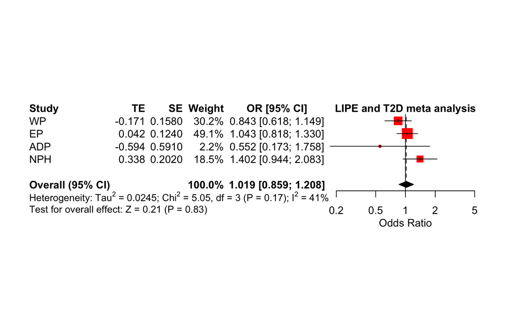

### TSC1

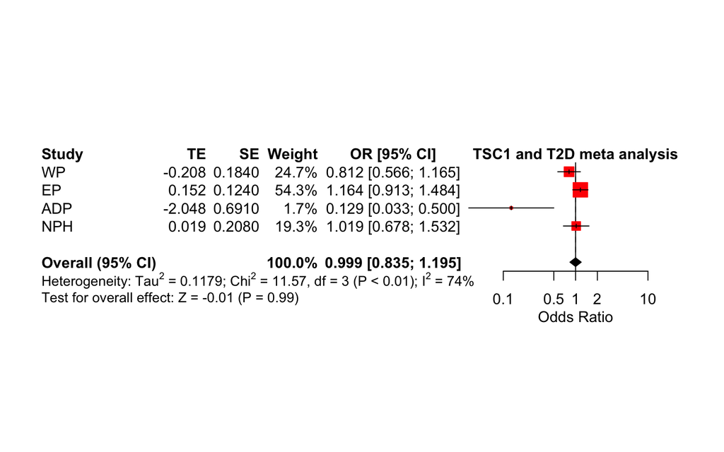

### WFS1

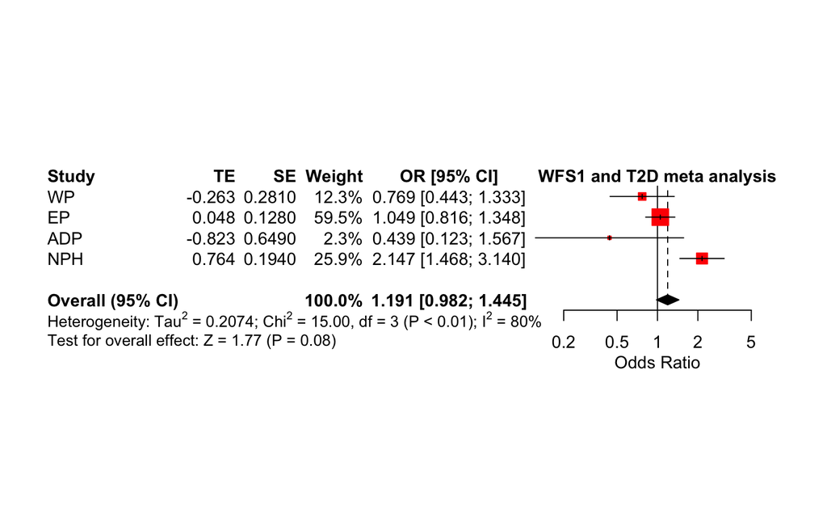

### CREB3L2

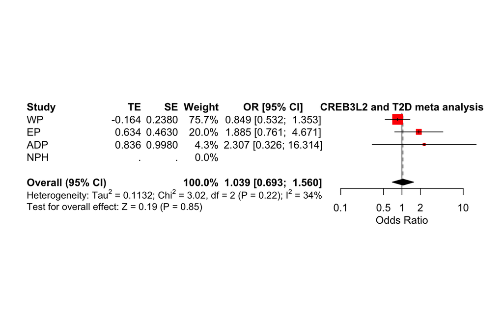

### SLC22A3

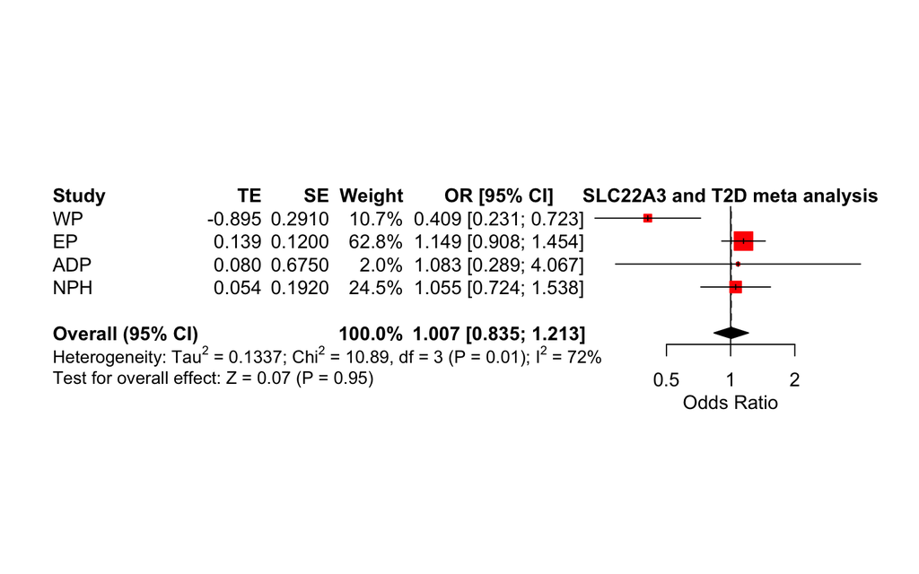

# BMI linear regressions

### Polynesian Wide

Linear regression of BMI in Polynesian Wide

| test | unadjusted n | unadjusted estimate | unadjusted std.error | unadjusted statistic | unadjusted p.value | adjusted n_adj | adjusted estimate_adj | adjusted std.error_adj | adjusted statistic_adj | adjusted p.value_adj |
| --- | --- | --- | --- | --- | --- | --- | --- | --- | --- | --- |
| LIPE (rs370955937) | 2489 | 1.491 | 0.268 | 5.563 | 2.939 x 10<sup>-8</sup> | 2110 | 0.870 | 0.295 | 2.947 | 0.003 |
| TSC1 (rs397514880) | 2523 | 0.527 | 0.289 | 1.822 | 0.069 | 2133 | 0.203 | 0.314 | 0.645 | 0.519 |
| WFS1 (rs756252214) | 2499 | -0.417 | 0.344 | -1.212 | 0.226 | 2117 | -0.818 | 0.370 | -2.210 | 0.027 |
| CREB3L2 (rs777894272) | 2486 | 1.701 | 0.523 | 3.250 | 0.001 | 2107 | 0.298 | 0.604 | 0.494 | 0.621 |
| SLC22A3 (rs8187715) | 2219 | 0.534 | 0.350 | 1.527 | 0.127 | 2217 | 0.220 | 0.354 | 0.621 | 0.535 |

**Note:**  
Covariates in the adjusted model are age, sex, PCs 1-10 and broad PCA ancestry

### West Polynesian

Linear regression of BMI in West Polynesian

| test | unadjusted n | unadjusted estimate | unadjusted std.error | unadjusted statistic | unadjusted p.value | adjusted n_adj | adjusted estimate_adj | adjusted std.error_adj | adjusted statistic_adj | adjusted p.value_adj |
| --- | --- | --- | --- | --- | --- | --- | --- | --- | --- | --- |
| LIPE (rs370955937) | 928 | 0.865 | 0.379 | 2.283 | 0.023 | 759 | 0.858 | 0.401 | 2.140 | 0.033 |
| TSC1 (rs397514880) | 933 | -0.439 | 0.432 | -1.017 | 0.309 | 762 | -0.484 | 0.468 | -1.034 | 0.301 |
| WFS1 (rs756252214) | 929 | -0.918 | 0.680 | -1.352 | 0.177 | 759 | -0.494 | 0.702 | -0.703 | 0.482 |
| CREB3L2 (rs777894272) | 927 | 0.237 | 0.573 | 0.414 | 0.679 | 758 | -0.470 | 0.622 | -0.756 | 0.450 |
| SLC22A3 (rs8187715) | 780 | 0.197 | 0.678 | 0.291 | 0.771 | 780 | 0.132 | 0.677 | 0.194 | 0.846 |

**Note:**  
Covariates in the adjusted model are age, sex, PCs 1-10 and broad PCA ancestry

### East Polynesian

Linear regression of BMI in East Polynesian

| test | unadjusted n | unadjusted estimate | unadjusted std.error | unadjusted statistic | unadjusted p.value | adjusted n_adj | adjusted estimate_adj | adjusted std.error_adj | adjusted statistic_adj | adjusted p.value_adj |
| --- | --- | --- | --- | --- | --- | --- | --- | --- | --- | --- |
| LIPE (rs370955937) | 1436 | 1.590 | 0.400 | 3.979 | 7.279 x 10<sup>-5</sup> | 1245 | 0.888 | 0.440 | 2.020 | 0.044 |
| TSC1 (rs397514880) | 1463 | 1.282 | 0.402 | 3.192 | 0.001 | 1265 | 0.972 | 0.439 | 2.215 | 0.027 |
| WFS1 (rs756252214) | 1444 | 0.189 | 0.425 | 0.444 | 0.657 | 1252 | -0.795 | 0.459 | -1.732 | 0.083 |
| CREB3L2 (rs777894272) | 1434 | 4.607 | 1.661 | 2.774 | 0.006 | 1243 | 3.690 | 1.700 | 2.170 | 0.030 |
| SLC22A3 (rs8187715) | 1329 | 0.987 | 0.426 | 2.319 | 0.021 | 1327 | 0.296 | 0.433 | 0.683 | 0.495 |

**Note:**  
Covariates in the adjusted model are age, sex, PCs 1-10 and broad PCA anestry

### Admixed Polynesian

Linear regression of BMI in Admixed Polynesian

| test | unadjusted n | unadjusted estimate | unadjusted std.error | unadjusted statistic | unadjusted p.value | adjusted n_adj | adjusted estimate_adj | adjusted std.error_adj | adjusted statistic_adj | adjusted p.value_adj |
| --- | --- | --- | --- | --- | --- | --- | --- | --- | --- | --- |
| LIPE (rs370955937) | 125 | 2.186 | 1.253 | 1.745 | 0.084 | 106 | 1.445 | 1.462 | 0.989 | 0.325 |
| TSC1 (rs397514880) | 127 | -1.525 | 1.229 | -1.241 | 0.217 | 106 | -2.811 | 1.524 | -1.844 | 0.068 |
| WFS1 (rs756252214) | 126 | -1.039 | 1.484 | -0.700 | 0.485 | 106 | -2.609 | 2.011 | -1.297 | 0.198 |
| CREB3L2 (rs777894272) | 125 | 3.007 | 2.093 | 1.436 | 0.153 | 106 | 2.478 | 2.674 | 0.927 | 0.357 |
| SLC22A3 (rs8187715) | 110 | 0.158 | 1.927 | 0.082 | 0.935 | 110 | 0.366 | 2.000 | 0.183 | 0.855 |

**Note:**  
Covariates in the adjusted model are age, sex, PCs 1-10 and broad PCA anestry

### Ngati Porou

Linear regression of BMI in Ngati Porou Hauora

| test | unadjusted n | unadjusted estimate | unadjusted std.error | unadjusted statistic | unadjusted p.value | adjusted n_adj | adjusted estimate_adj | adjusted std.error_adj | adjusted statistic_adj | adjusted p.value_adj |
| --- | --- | --- | --- | --- | --- | --- | --- | --- | --- | --- |
| LIPE (rs370955937) | 514 | 1.286 | 0.652 | 1.974 | 0.049 | 509 | 1.433 | 0.661 | 2.167 | 0.031 |
| TSC1 (rs397514880) | 523 | 0.095 | 0.674 | 0.142 | 0.887 | 518 | 0.089 | 0.685 | 0.130 | 0.897 |
| WFS1 (rs756252214) | 516 | 1.557 | 0.632 | 2.462 | 0.014 | 511 | 1.741 | 0.643 | 2.705 | 0.007 |
| SLC22A3 (rs8187715) | 531 | -0.131 | 0.631 | -0.207 | 0.836 | 526 | -0.014 | 0.635 | -0.022 | 0.982 |

**Note:**  
Covariates in the adjusted model are age, sex and GPancestry

# BMI Meta Analyses

### LIPE

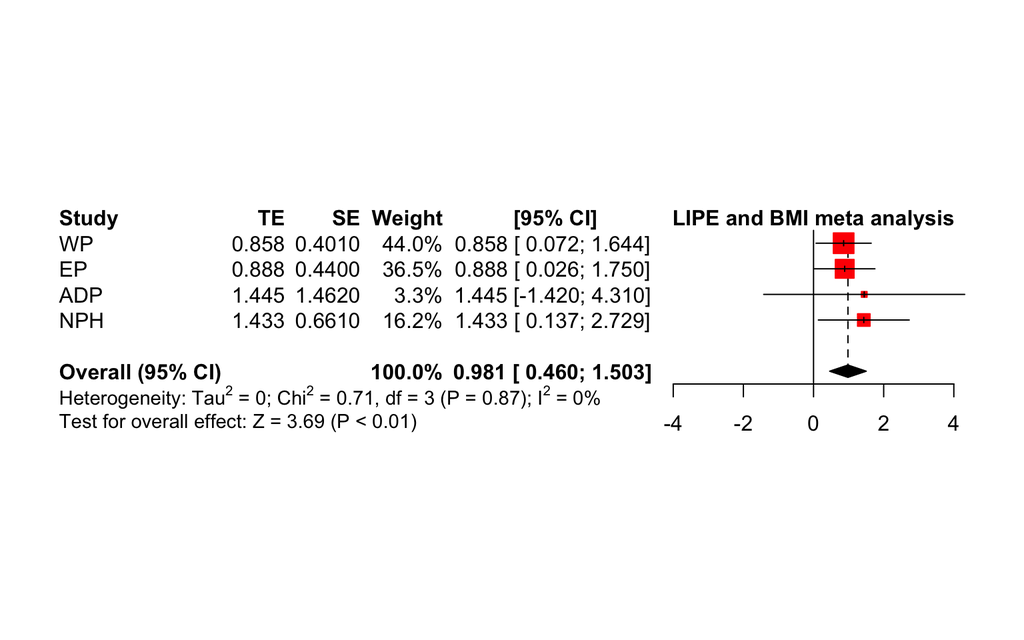

### TSC1

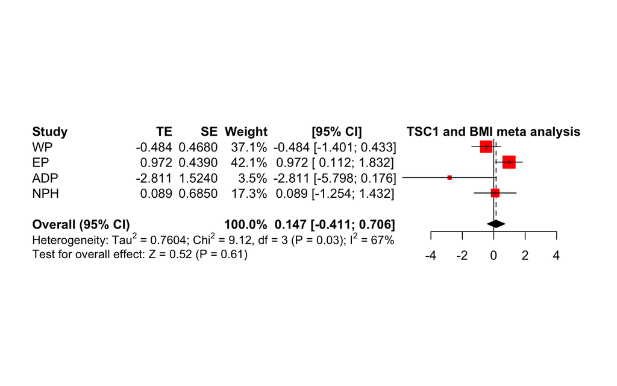

### WFS1

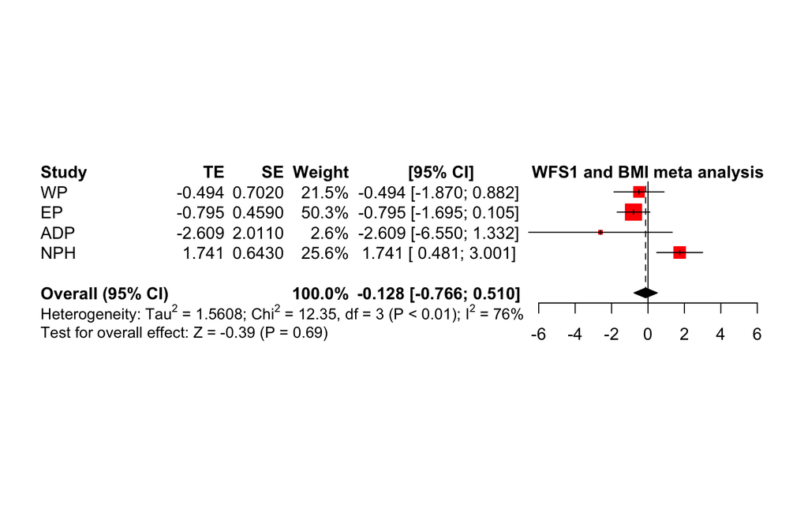

### CREB3L2

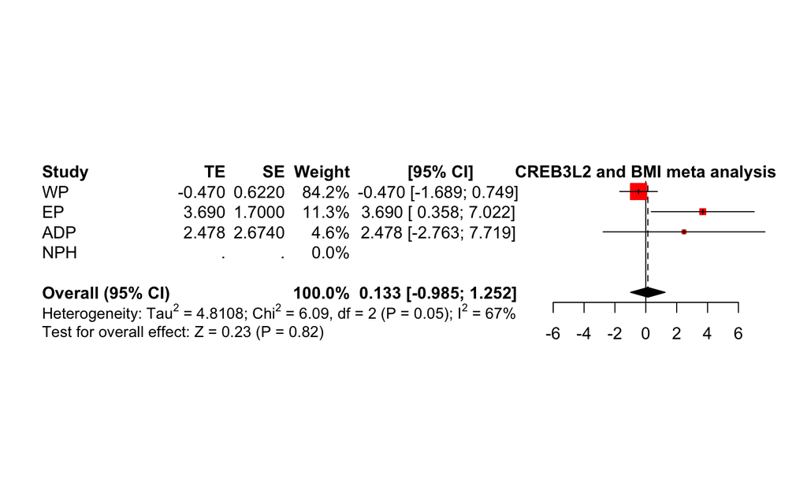

### SLC22A3

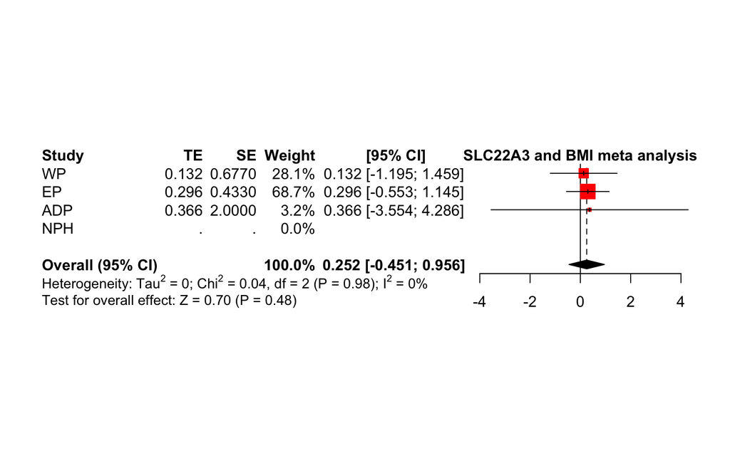

# LIPE assocations with BMI related phenotypes

Linear regression of BMI related phenotypes

| Phenotype | unadjusted n | unadjusted estimate | unadjusted std.error | unadjusted statistic | unadjusted p.value | adjusted n_adj | adjusted estimate_adj | adjusted std.error_adj | adjusted statistic_adj | adjusted p.value_adj |
| --- | --- | --- | --- | --- | --- | --- | --- | --- | --- | --- |
| **Polynesian wide** |  |  |  |  |  |  |  |  |  |  |
|  | NA | NA | NA | NA | NA | NA | NA | NA | NA | NA |
| Triglycerides | 2226 | 0.033 | 0.070 | 0.475 | 0.635 | 1865 | -0.007 | 0.060 | -0.114 | 0.909 |
| LDL | 2062 | -0.005 | 0.037 | -0.134 | 0.893 | 1739 | -0.003 | 0.042 | -0.072 | 0.942 |
| Height | 2508 | -0.055 | 0.327 | -0.169 | 0.866 | 2125 | -0.146 | 0.270 | -0.540 | 0.589 |
| Waist | 2176 | 3.173 | 0.632 | 5.025 | 5.446 x 10<sup>-7</sup> | 1832 | 1.554 | 0.684 | 2.273 | 0.023 |
| **West Polynesian** |  |  |  |  |  |  |  |  |  |  |
|  | NA | NA | NA | NA | NA | NA | NA | NA | NA | NA |
| Triglycerides | 858 | -0.117 | 0.084 | -1.386 | 0.166 | 695 | -0.094 | 0.086 | -1.092 | 0.275 |
| LDL | 796 | 0.003 | 0.056 | 0.053 | 0.958 | 650 | -0.025 | 0.063 | -0.401 | 0.688 |
| Height | 939 | 0.253 | 0.485 | 0.520 | 0.603 | 768 | -0.366 | 0.380 | -0.963 | 0.336 |
| Waist | 830 | 2.957 | 0.880 | 3.360 | 8.150 x 10<sup>-4</sup> | 676 | 2.748 | 0.938 | 2.930 | 0.004 |
| **East Polynesian** |  |  |  |  |  |  |  |  |  |  |
|  | NA | NA | NA | NA | NA | NA | NA | NA | NA | NA |
| Triglycerides | 1249 | 0.208 | 0.105 | 1.987 | 0.047 | 1070 | 0.019 | 0.089 | 0.213 | 0.831 |
| LDL | 1156 | -0.021 | 0.053 | -0.397 | 0.691 | 997 | 0.024 | 0.059 | 0.400 | 0.689 |
| Height | 1444 | -0.902 | 0.479 | -1.885 | 0.060 | 1252 | 0.161 | 0.398 | 0.404 | 0.686 |
| Waist | 1230 | 2.235 | 0.955 | 2.340 | 0.019 | 1057 | 0.366 | 1.018 | 0.360 | 0.719 |
| **Admixed Polynesian** |  |  |  |  |  |  |  |  |  |  |
|  | NA | NA | NA | NA | NA | NA | NA | NA | NA | NA |
| Triglycerides | 119 | 0.063 | 0.547 | 0.114 | 0.909 | 100 | 0.461 | 0.231 | 1.997 | 0.049 |
| LDL | 110 | -0.079 | 0.163 | -0.486 | 0.628 | 92 | -0.116 | 0.193 | -0.601 | 0.550 |
| Height | 125 | -0.992 | 1.288 | -0.770 | 0.443 | 105 | -1.093 | 1.169 | -0.935 | 0.352 |
| Waist | 116 | 3.361 | 3.021 | 1.113 | 0.268 | 99 | 2.443 | 3.556 | 0.687 | 0.494 |
| **Ngati Porou Hauora** |  |  |  |  |  |  |  |  |  |  |
|  | NA | NA | NA | NA | NA | NA | NA | NA | NA | NA |
| Triglycerides | 540 | 0.072 | 0.121 | 0.596 | 0.551 | 291 | -0.030 | 0.180 | -0.169 | 0.866 |
| LDL | 486 | -0.104 | 0.087 | -1.196 | 0.232 | 255 | -0.086 | 0.123 | -0.699 | 0.486 |
| Height | 515 | 0.967 | 0.751 | 1.288 | 0.198 | 279 | 0.334 | 0.706 | 0.473 | 0.636 |
| Waist | 408 | 3.465 | 1.670 | 2.075 | 0.039 | 249 | 2.705 | 2.096 | 1.290 | 0.198 |

**Note:**  
Covariates in the adjusted model are age, sex, PCs 1-10 and broad PCA ancestry

# LIPE and Waist Meta-analysis

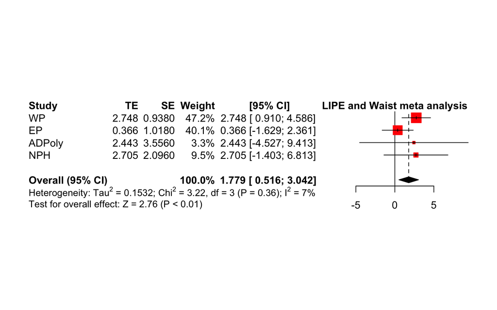

# Logistic regression of LIPE and SLC22A3 with Gout

Logistic regression of LIPE and SLC22A3 with Gout

[output not shown]

**Note:**  
Covariates in the adjusted model are age, sex, PCs 1-10 and broad PCA ancestry. Ngati Porou Hauora is adjusted with Grandparental ancestry rather than PCA’s

# Gout Meta-analysis

### LIPE

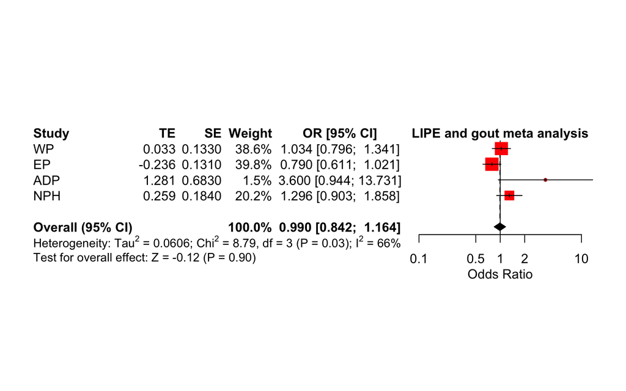

### SLC22A3

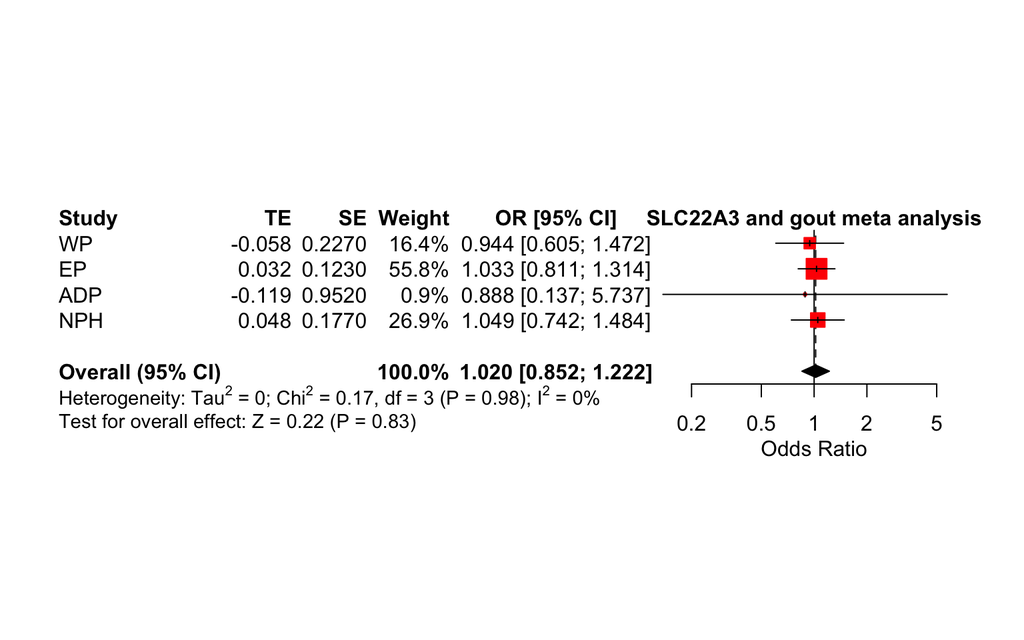

Call: glm(formula = as.numeric(as.character(GPGOUTAFFSTAT)) ~ RS777894272_down * RS373863828_down, family = binomial, data = westpoly)

Deviance Residuals: Min 1Q Median 3Q Max  
-1.4573 -1.1361 0.9213 1.1798 1.2193

Coefficients: Estimate Std. Error z value Pr(>|z|) (Intercept) -0.09793 0.09527 -1.028 0.304 RS777894272_down 0.09228 0.20687 0.446 0.656 RS373863828_down 0.18499 0.13505 1.370 0.171 RS777894272_down:RS373863828_down 0.13654 0.28849 0.473 0.636

(Dispersion parameter for binomial family taken to be 1)

```
Null deviance: 1122.9  on 809  degrees of freedom
```

Residual deviance: 1118.6 on 806 degrees of freedom (264 observations deleted due to missingness) AIC: 1126.6

Number of Fisher Scoring iterations: 4

Call: glm(formula = as.numeric(as.character(GPGOUTAFFSTAT)) ~ RS777894272_down * RS373863828_down + as.numeric(AGECOL) + as.factor(SEX) + PCA1 + PCA2 + PCA3 + PCA4 + PCA5 + PCA6 + PCA7 + PCA8 + PCA9 + PCA10 + as.numeric(PCAETHBROAD_down), family = binomial, data = westpoly)

Deviance Residuals: Min 1Q Median 3Q Max  
-2.1448 -0.8557 0.4055 0.8597 2.2913

Coefficients: Estimate Std. Error z value Pr(>|z|) (Intercept) -4.417e+00 1.480e+00 -2.984 0.002845 RS777894272_down -2.083e-01 2.587e-01 -0.805 0.420693 RS373863828_down 1.357e-01 1.709e-01 0.794 0.427435 as.numeric(AGECOL) 4.747e-02 6.659e-03 7.129 1.01e-12 as.factor(SEX)2 -2.188e+00 2.116e-01 -10.342 < 2e-16 PCA1 -2.748e+02 1.388e+02 -1.980 0.047754 PCA2 1.651e+02 6.710e+01 2.461 0.013863 PCA3 -6.128e+01 2.324e+01 -2.637 0.008373 PCA4 -7.608e+00 1.902e+01 -0.400 0.689140 PCA5 1.532e+01 4.007e+00 3.824 0.000131 PCA6 1.636e+01 1.719e+01 0.952 0.341257 PCA7 1.302e+01 1.336e+01 0.975 0.329686 PCA8 -8.496e+00 1.440e+01 -0.590 0.555275 PCA9 -3.334e+01 1.460e+01 -2.283 0.022428 PCA10 1.985e+01 8.973e+00 2.213 0.026917 as.numeric(PCAETHBROAD_down) 2.074e-01 2.187e-01 0.948 0.342954 RS777894272_down:RS373863828_down 2.169e-01 3.669e-01 0.591 0.554512

(Intercept) ** RS777894272_down  
RS373863828_down  
as.numeric(AGECOL) *as.factor(SEX)2* PCA1 *  
PCA2 *  
PCA3 ** PCA4  
PCA5 ** PCA6  
PCA7  
PCA8  
PCA9  
PCA10 *  
as.numeric(PCAETHBROAD_down)  
RS777894272_down:RS373863828_down  
— Signif. codes: 0 ‘**’ 0.001 ’**’ 0.01 ’’ 0.05 ‘.’ 0.1 ‘’ 1

(Dispersion parameter for binomial family taken to be 1)

```
Null deviance: 1042.45  on 751  degrees of freedom
```

Residual deviance: 795.69 on 735 degrees of freedom (322 observations deleted due to missingness) AIC: 829.69

Number of Fisher Scoring iterations: 4

Call: glm(formula = as.numeric(as.character(GPGOUTAFFSTAT)) ~ RS777894272_down * RS373863828_down, family = binomial, data = eastpoly)

Deviance Residuals: Min 1Q Median 3Q Max  
-1.781 -1.043 -1.031 1.318 1.615

Coefficients: Estimate Std. Error z value Pr(>|z|)  
(Intercept) -0.32562 0.06610 -4.926 8.4e-07 ** *RS777894272_down 1.68240 0.67967 2.475 0.0133*  
RS373863828_down -0.02936 0.11197 -0.262 0.7932  
RS777894272_down:RS373863828_down -1.14276 0.74981 -1.524 0.1275  
— Signif. codes: 0 ‘**’ 0.001 ’**’ 0.01 ’’ 0.05 ‘.’ 0.1 ‘’ 1

(Dispersion parameter for binomial family taken to be 1)

```
Null deviance: 1780.7  on 1307  degrees of freedom
```

Residual deviance: 1772.8 on 1304 degrees of freedom (541 observations deleted due to missingness) AIC: 1780.8

Number of Fisher Scoring iterations: 4

Call: glm(formula = as.numeric(as.character(GPGOUTAFFSTAT)) ~ RS777894272_down * RS373863828_down + as.numeric(AGECOL) + as.factor(SEX) + PCA1 + PCA2 + PCA3 + PCA4 + PCA5 + PCA6 + PCA7 + PCA8 + PCA9 + PCA10 + as.numeric(PCAETHBROAD_down), family = binomial, data = eastpoly)

Deviance Residuals: Min 1Q Median 3Q Max  
-2.2675 -0.8247 -0.4132 0.9110 2.5398

Coefficients: Estimate Std. Error z value Pr(>|z|) (Intercept) -2.998930 0.420916 -7.125 1.04e-12 RS777894272_down 2.504641 0.890543 2.812 0.00492 RS373863828_down -0.083806 0.139902 -0.599 0.54915 as.numeric(AGECOL) 0.062508 0.005313 11.766 < 2e-16 as.factor(SEX)2 -1.800485 0.145906 -12.340 < 2e-16 PCA1 1.598059 45.197948 0.035 0.97180 PCA2 10.254101 23.745415 0.432 0.66586 PCA3 8.322635 19.128293 0.435 0.66349 PCA4 -7.796679 15.992252 -0.488 0.62588 PCA5 5.479376 9.893014 0.554 0.57967 PCA6 29.188714 14.979433 1.949 0.05134 PCA7 -3.155138 11.371696 -0.277 0.78143 PCA8 -0.900292 10.259423 -0.088 0.93007 PCA9 2.482239 11.185890 0.222 0.82439 PCA10 -19.897864 9.665973 -2.059 0.03954 as.numeric(PCAETHBROAD_down) -0.003202 0.063113 -0.051 0.95954 RS777894272_down:RS373863828_down -1.353933 0.950402 -1.425 0.15428

(Intercept) **RS777894272_down** RS373863828_down  
as.numeric(AGECOL) **as.factor(SEX)2** PCA1  
PCA2  
PCA3  
PCA4  
PCA5  
PCA6 .  
PCA7  
PCA8  
PCA9  
PCA10  
as.numeric(PCAETHBROAD_down)  
RS777894272_down:RS373863828_down  
— Signif. codes: 0 ‘**’ 0.001 ’**’ 0.01 ’’ 0.05 ‘.’ 0.1 ‘’ 1

(Dispersion parameter for binomial family taken to be 1)

```
Null deviance: 1674.8  on 1233  degrees of freedom
```

Residual deviance: 1312.0 on 1217 degrees of freedom (615 observations deleted due to missingness) AIC: 1346

Number of Fisher Scoring iterations: 4

Call: glm(formula = as.numeric(as.character(GPGOUTAFFSTAT)) ~ RS777894272_down * RS373863828_down, family = binomial, data = adpoly)

Deviance Residuals: Min 1Q Median 3Q Max  
-1.1774 -0.8911 -0.8191 1.4852 1.5845

Coefficients: Estimate Std. Error z value Pr(>|z|)  
(Intercept) -0.9198 0.2697 -3.411 0.000648 *** RS777894272_down 0.9198 0.8599 1.070 0.284776  
RS373863828_down 0.2010 0.3596 0.559 0.576188  
RS777894272_down:RS373863828_down -0.8942 1.2434 -0.719 0.472054  
— Signif. codes: 0 ‘**’ 0.001 ’**’ 0.01 ’’ 0.05 ‘.’ 0.1 ‘’ 1

(Dispersion parameter for binomial family taken to be 1)

```
Null deviance: 134.55  on 107  degrees of freedom
```

Residual deviance: 133.27 on 104 degrees of freedom (44 observations deleted due to missingness) AIC: 141.27

Number of Fisher Scoring iterations: 4

Call: glm(formula = as.numeric(as.character(GPGOUTAFFSTAT)) ~ RS777894272_down * RS373863828_down + as.numeric(AGECOL) + as.factor(SEX) + PCA1 + PCA2 + PCA3 + PCA4 + PCA5 + PCA6 + PCA7 + PCA8 + PCA9 + PCA10 + as.numeric(PCAETHBROAD_down), family = binomial, data = adpoly)

Deviance Residuals: Min 1Q Median 3Q Max  
-1.5083 -0.4112 -0.1017 0.2686 3.2422

Coefficients: Estimate Std. Error z value Pr(>|z|) (Intercept) -1.810e+01 5.077e+00 -3.564 0.000365 RS777894272_down 1.401e+00 1.191e+00 1.176 0.239554 RS373863828_down 1.388e+00 8.143e-01 1.705 0.088180 as.numeric(AGECOL) 8.880e-02 3.083e-02 2.881 0.003970 as.factor(SEX)2 -3.042e+00 9.948e-01 -3.058 0.002226 PCA1 -1.725e+03 7.348e+02 -2.348 0.018868 PCA2 1.052e+03 3.828e+02 2.748 0.005998 PCA3 -1.657e+02 1.205e+02 -1.375 0.169098 PCA4 -1.481e+01 8.194e+01 -0.181 0.856574 PCA5 4.227e+01 1.615e+01 2.617 0.008860 PCA6 1.348e+02 7.904e+01 1.705 0.088132 PCA7 2.810e+00 5.614e+01 0.050 0.960081 PCA8 1.931e+01 6.341e+01 0.305 0.760691 PCA9 -1.663e+02 6.915e+01 -2.405 0.016170 PCA10 3.789e+01 4.150e+01 0.913 0.361239 as.numeric(PCAETHBROAD_down) 1.193e+00 5.135e-01 2.323 0.020188 RS777894272_down:RS373863828_down -1.023e+00 2.330e+00 -0.439 0.660521

(Intercept) * RS777894272_down  
RS373863828_down .  
as.numeric(AGECOL) as.factor(SEX)2 PCA1 *  
PCA2 PCA3  
PCA4  
PCA5 ** PCA6 .  
PCA7  
PCA8  
PCA9 *  
PCA10  
as.numeric(PCAETHBROAD_down) *  
RS777894272_down:RS373863828_down  
— Signif. codes: 0 ‘**’ 0.001 ’**’ 0.01 ’’ 0.05 ‘.’ 0.1 ‘’ 1

(Dispersion parameter for binomial family taken to be 1)

```
Null deviance: 129.117  on 104  degrees of freedom
```

Residual deviance: 60.131 on 88 degrees of freedom (47 observations deleted due to missingness) AIC: 94.131

Number of Fisher Scoring iterations: 7

Call: glm(formula = as.numeric(as.character(GOUTAFFSTAT)) ~ RS777894272_down * RS373863828_down, family = binomial, data = mydataNPH)

Deviance Residuals: Min 1Q Median 3Q Max  
-1.250 -1.250 1.106 1.106 1.184

Coefficients: Estimate Std. Error z value Pr(>|z|) (Intercept) 0.16943 0.10489 1.615 0.106 RS777894272_down -14.73550 882.74338 -0.017 0.987 RS373863828_down -0.09265 0.15874 -0.584 0.559 RS777894272_down:RS373863828_down 29.22479 1081.13543 0.027 0.978

(Dispersion parameter for binomial family taken to be 1)

```
Null deviance: 712.81  on 515  degrees of freedom
```

Residual deviance: 708.44 on 512 degrees of freedom (69 observations deleted due to missingness) AIC: 716.44

Number of Fisher Scoring iterations: 13

Call: glm(formula = as.numeric(as.character(GOUTAFFSTAT)) ~ RS777894272_down * RS373863828_down + as.numeric(AGECOL) + as.factor(SEX) + as.numeric(GPANCESTRY), family = binomial, data = mydataNPH)

Deviance Residuals: Min 1Q Median 3Q Max  
-2.3948 -0.9597 0.5560 0.8986 2.3936

Coefficients: Estimate Std. Error z value Pr(>|z|) (Intercept) -1.926e+00 5.717e-01 -3.369 0.000753 RS777894272_down -1.649e+01 1.455e+03 -0.011 0.990959 RS373863828_down -4.771e-03 1.816e-01 -0.026 0.979040 as.numeric(AGECOL) 5.395e-02 7.297e-03 7.393 1.43e-13 as.factor(SEX)2 -1.405e+00 2.213e-01 -6.349 2.16e-10 as.numeric(GPANCESTRY) -4.472e-01 4.573e-01 -0.978 0.328120 RS777894272_down:RS373863828_down 3.247e+01 1.670e+03 0.019 0.984491

(Intercept) RS777894272_down  
RS373863828_down  
as.numeric(AGECOL) as.factor(SEX)2 *** as.numeric(GPANCESTRY)  
RS777894272_down:RS373863828_down  
— Signif. codes: 0 ‘**’ 0.001 ’**’ 0.01 ’’ 0.05 ‘.’ 0.1 ‘’ 1

(Dispersion parameter for binomial family taken to be 1)

```
Null deviance: 704.18  on 509  degrees of freedom
```

Residual deviance: 584.97 on 503 degrees of freedom (75 observations deleted due to missingness) AIC: 598.97

Number of Fisher Scoring iterations: 14